```python
import functools
import itertools
import operator
from matplotlib import pyplot as plt

import pandas as pd
from pandas.api.types import is_numeric_dtype
import numpy as np
import numpy_ext as npe
import math
from pprint import pprint
from scipy.optimize import curve_fit
from scipy.stats import poisson


import seaborn as sns
```

# Setup

Read file with a selection of patients according to the following criteria:

- age >= 18 years
- ventilated for >= 24 hours
- length of ICU stay >= 72 hours
- known hospital mortality or 90-day-mortality

Data is assumed to be sampled and/or aggregated by periods of 4 hours for the entire ICU stay, i.e. including after and prior to mechanical ventilation.

```python
file = 'ventilatedpatients.csv'
SAMPLE_TIME_H = 4 # each row corresponds to 4 hour of icu stay
```

```python
df = pd.read_csv(file)
```

```python
df.describe()
```

|  | icustay_id | subject_id | hadm_id | admission_age | weight | adult_ibw | elixhauser_vanwalraven | sofa | sirs | gcs | ... | fio2 | urineoutput | vaso_total | iv_total | cum_fluid_balance | peep | tidal_volume | volume_controlled | plateau_pressure | hours_mechvent |
| --- | --- | --- | --- | --- | --- | --- | --- | --- | --- | --- | --- | --- | --- | --- | --- | --- | --- | --- | --- | --- | --- |
| count | 752953.000000 | 752953.000000 | 752953.000000 | 752953.000000 | 7.035080e+05 | 672351.000000 | 175404.000000 | 752953.000000 | 752953.000000 | 608961.000000 | ... | 543952.000000 | 642229.000000 | 84251.000000 | 641795.000000 | 725841.000000 | 481171.000000 | 480816.000000 | 258627.0 | 136433.000000 | 752953.000000 |
| mean | 249996.586107 | 32498.429364 | 150345.359021 | 70.603218 | 2.579501e+02 | 63.427122 | 9.826783 | 4.431022 | 1.125560 | 10.076688 | ... | 47.016707 | 363.053721 | 1.704427 | 330.248053 | -17891.578745 | 7.065551 | 514.790853 | 1.0 | 22.907549 | 340.573805 |
| std | 28673.880176 | 27683.663461 | 28719.155699 | 44.248143 | 1.995614e+04 | 13.561957 | 7.650886 | 2.595107 | 0.893306 | 3.549177 | ... | 11.509916 | 740.936061 | 15.706878 | 728.065368 | 43145.081680 | 3.377778 | 970.868869 | 0.0 | 6.599175 | 355.787073 |
| min | 200003.000000 | 3.000000 | 100011.000000 | 18.057966 | 7.400000e+00 | -1.228000 | -10.000000 | 0.000000 | 0.000000 | 3.000000 | ... | 20.999999 | -8550.000000 | 0.000500 | 0.000000 | -908687.361249 | -9.500000 | 0.000000 | 1.0 | 0.000000 | 24.000000 |
| 25% | 225260.000000 | 11382.000000 | 125875.000000 | 53.228207 | 7.000000e+01 | 54.245600 | 5.000000 | 3.000000 | 0.000000 | 8.000000 | ... | 40.000001 | 150.000000 | 0.080000 | 52.997133 | -19738.887143 | 5.000000 | 422.000000 | 1.0 | 18.200001 | 108.000000 |
| 50% | 250285.000000 | 23238.000000 | 150007.000000 | 66.087504 | 8.294000e+01 | 63.868400 | 9.000000 | 4.000000 | 1.000000 | 10.000000 | ... | 40.000001 | 275.000000 | 0.227273 | 128.333333 | -8985.654091 | 5.000000 | 500.000000 | 1.0 | 22.000000 | 232.000000 |
| 75% | 274671.000000 | 51459.000000 | 175345.000000 | 77.019782 | 9.848000e+01 | 73.114000 | 15.000000 | 6.000000 | 2.000000 | 13.000000 | ... | 50.000000 | 480.000000 | 0.568182 | 310.000000 | -2827.349801 | 8.000000 | 590.000000 | 1.0 | 27.000000 | 460.000000 |
| max | 299994.000000 | 99985.000000 | 199994.000000 | 309.637886 | 3.295995e+06 | 316.266000 | 43.000000 | 21.000000 | 4.000000 | 15.000000 | ... | 100.000000 | 451310.000000 | 3569.999979 | 290133.333333 | 533921.338370 | 101.000000 | 593593.000000 | 1.0 | 77.000000 | 3004.000000 |

8 rows × 56 columns

```python
df.columns
```

```
Index(['icustay_id', 'subject_id', 'hadm_id', 'intime', 'outtime',
       'start_time', 'admission_age', 'gender', 'weight', 'adult_ibw',
       'icu_readmission', 'elixhauser_vanwalraven', 'sofa', 'sirs', 'gcs',
       'heartrate', 'sysbp', 'diasbp', 'meanbp', 'shockindex', 'resprate',
       'tempc', 'spo2', 'potassium', 'sodium', 'chloride', 'glucose', 'bun',
       'creatinine', 'magnesium', 'calcium', 'ionizedcalcium', 'carbondioxide',
       'sgot', 'sgpt', 'bilirubin', 'albumin', 'hemoglobin', 'wbc', 'platelet',
       'ptt', 'pt', 'inr', 'ph', 'pao2', 'paco2', 'base_excess', 'bicarbonate',
       'lactate', 'pao2fio2ratio', 'mechvent', 'fio2', 'urineoutput',
       'vaso_total', 'iv_total', 'cum_fluid_balance', 'peep', 'tidal_volume',
       'volume_controlled', 'plateau_pressure', 'hospmort', 'mort90day',
       'dischtime', 'deathtime', 'hours_mechvent'],
      dtype='object')
```

```python
df[df.mechvent==True].head()
```

|  | icustay_id | subject_id | hadm_id | intime | outtime | start_time | admission_age | gender | weight | adult_ibw | ... | cum_fluid_balance | peep | tidal_volume | volume_controlled | plateau_pressure | hospmort | mort90day | dischtime | deathtime | hours_mechvent |
| --- | --- | --- | --- | --- | --- | --- | --- | --- | --- | --- | --- | --- | --- | --- | --- | --- | --- | --- | --- | --- | --- |
| 6 | 200003 | 27513 | 163557 | 2199-08-02 19:50:04 | 2199-08-08 17:09:18 | 2199-08-03 17:40:00 | 48.296271 | M | 78.633331 | 73.114 | ... | -3619.571625 | 10.0 | 605.0 | 1.0 | 22.0 | f | t | 2199-08-22 19:00:00 | NaN | 92 |
| 7 | 200003 | 27513 | 163557 | 2199-08-02 19:50:04 | 2199-08-08 17:09:18 | 2199-08-03 21:40:00 | 48.296271 | M | 78.633331 | 73.114 | ... | -4048.991041 | 10.0 | 587.0 | 1.0 | 24.0 | f | t | 2199-08-22 19:00:00 | NaN | 92 |
| 8 | 200003 | 27513 | 163557 | 2199-08-02 19:50:04 | 2199-08-08 17:09:18 | 2199-08-04 01:40:00 | 48.296271 | M | 78.633331 | 73.114 | ... | -4034.088542 | 10.0 | 606.5 | 1.0 | 22.0 | f | t | 2199-08-22 19:00:00 | NaN | 92 |
| 9 | 200003 | 27513 | 163557 | 2199-08-02 19:50:04 | 2199-08-08 17:09:18 | 2199-08-04 05:40:00 | 48.296271 | M | 78.633331 | 73.114 | ... | -4196.298543 | 5.0 | 626.0 | 1.0 | 17.0 | f | t | 2199-08-22 19:00:00 | NaN | 92 |
| 10 | 200003 | 27513 | 163557 | 2199-08-02 19:50:04 | 2199-08-08 17:09:18 | 2199-08-04 09:40:00 | 48.296271 | M | 78.633331 | 73.114 | ... | -4380.243545 | 5.0 | 615.5 | 1.0 | 16.0 | f | t | 2199-08-22 19:00:00 | NaN | 92 |

5 rows × 65 columns

## Preprocessing phase 1

Set some time stamps

```python
timestamps = [
    'start_time',
    'intime',
    'outtime',
]
for col in timestamps:
    df[col] = pd.to_datetime(df[col])
```

```python
def start_mechvent(grouped_df):
    tv0 = grouped_df.tidal_volume
    tv1 = tv0.shift(-1)
    tv2 = tv0.shift(-2)
    peep0 = grouped_df.peep
    peep1 = peep0.shift(-1)
    peep2 = peep0.shift(-2)
    fio20 = grouped_df.fio2
    fio21 = fio20.shift(-1)
    fio22 = fio20.shift(-2)
    return ~tv0.isna() & (~tv1.isna() | ~peep1.isna() | ~fio21.isna()) & (~tv2.isna() | ~peep2.isna() | ~fio21.isna())
mechvents = df.groupby('icustay_id').apply(start_mechvent)
df['mechvent_peine'] = mechvents.reset_index().set_index('level_1').drop('icustay_id', axis=1)
df['mechvent_start_peine'] = df['mechvent_peine'].rolling(window=2, closed='left').apply(
    lambda x: not(x[0]) and x[1], raw=True).reset_index().set_index('index').shift(-1)
```

```python
print("Unique mechvent events: {}".format(df.mechvent_start_peine.sum()))
print("Unique ICU stays with > 1 mechvent event: {}".format((df.groupby('icustay_id')['mechvent_start_peine'].sum() > 0).sum()))
```

```
Unique mechvent events: 43832.0
Unique ICU stays with > 1 mechvent event: 10979
```

Add the admission time for each icustay as `start_time_icustay`

```python
df = df.merge(df.groupby('icustay_id', as_index=False)['start_time'].min(), on='icustay_id', how='left').rename(
    columns={'start_time_x': 'start_time', 'start_time_y': 'start_time_icustay'})
```

# Analyze missing values

```python
def print_missing_pct(dataframe, variables):
    """
    Formatted print of the number of NaNs in `dataframe` for each variable in `variables`.
    """
    ljust = max(map(len, variables))
    for var in variables:
        print('{} {}'.format(var.ljust(ljust), dataframe[var].isna().mean()))
```

## Demographics

Analyze the missing data per patient for demographics:

- Age
- Gender
- Weight (upon admission)
- ICU readmission
- Premorbidity as calculated by exlixhauser vanWalraven score by previous hospital stay

```python
# Note that demographics do not change over time, so we can take any value. We take the first.
identifiers = ['icustay_id',]

patients = df.drop_duplicates(identifiers, keep='first')
demographics = ['admission_age', 'gender', 'weight', 'adult_ibw', 'icu_readmission', 'elixhauser_vanwalraven']

print_missing_pct(patients, demographics)
```

```
admission_age          0.0
gender                 0.0
weight                 0.11378059836808703
adult_ibw              0.13644605621033545
icu_readmission        0.0
elixhauser_vanwalraven 0.7666364460562103
```

## Vital signs

Analyze missing data across the entire dataset for vital signs. These can be composed of both lab and chart data:

- SOFA: sequential organ failure, see [code](https://github.com/MIT-LCP/mimic-code/blob/master/concepts/severityscores/sofa.sql)
- SIRS: systemic inflammatory response syndrome (SIRS) score, see [code](https://github.com/MIT-LCP/mimic-code/blob/master/concepts/severityscores/sirs.sql)
- GCS: glascow coma score, see [code](https://github.com/MIT-LCP/mimic-code/blob/master/concepts/pivot/pivoted-gcs.sql)
- HR: heartrate, averaged over period
- SysBP: systolic blood pressure, averaged over period
- MeanBP: mean arterial pressure, averaged over period
- DiasBP: diastolic blood pressure, averaged over period
- Shock Index: SysBP / HeartRate, averaged over period
- RespRate: respiratory rate, averaged over period
- SpO2: blood oxygenation saturation, averaged over period
- TempC: temperature in Celsius, averaged over period

```python
vital_sign_vars = [
    'sofa',
    'sirs',
    'gcs',
    'heartrate',
    'sysbp',
    'meanbp',
    'diasbp',
    'shockindex',
    'resprate',
    'spo2',
    'tempc',
]
print_missing_pct(df, vital_sign_vars)
```

```
sofa       0.0
sirs       0.0
gcs        0.19123637199134608
heartrate  0.013975639913779479
sysbp      0.024666878277927042
meanbp     0.018025029450709405
diasbp     0.024705393298120864
shockindex 0.03208965234217807
resprate   0.01712855915309455
spo2       0.021494037476442754
tempc      0.09468320067786436
```

## Lab measurements

All are averaged over the time span

- potassium
- sodium
- chloride
- glucose
- bun: blood urea nitrogen
- creatinine
- magnesium
- calcium
- ionizedcalcium
- carbondioxide
- bilirubin
- albumin
- hemoglobin
- wbc: white blood cell count
- platelet: platelets count
- ptt: Partial Thromboplastin Time
- pt: Prothrombin Time
- inr: International Normalized Ratio
- ph
- pao2
- paco2
- base_ excess
- bicarbonate
- lactate
- pao2fio2ratio

```python
lab_vars = [
    'potassium',
    'sodium',
    'chloride',
    'glucose',
    'bun',
    'creatinine',
    'magnesium',
    'calcium',
    'ionizedcalcium',
    'carbondioxide',
    'bilirubin',
    'albumin',
    'hemoglobin',
    'wbc',
    'platelet',
    'ptt',
    'pt',
    'inr',
    'ph',
    'pao2',
    'paco2',
    'base_excess',
    'bicarbonate',
    'lactate',
    'pao2fio2ratio',
]
print_missing_pct(df, lab_vars)
```

```
potassium      0.9596203215871376
sodium         0.9605486663842232
chloride       0.9604782768645587
glucose        0.9625209010389759
bun            0.9599271136445435
creatinine     0.9598368025627098
magnesium      0.9640694704715965
calcium        0.9684708076068493
ionizedcalcium 0.8289136240907466
carbondioxide  0.9456181195904658
bilirubin      0.9864546658290757
albumin        0.990330073723061
hemoglobin     0.9625209010389759
wbc            0.9626869140570526
platelet       0.9607863970261092
ptt            0.9667708343017426
pt             0.9665596657427489
inr            0.9665609938468935
ph             0.9443723579028173
pao2           0.9798247699391596
paco2          0.9495174333590543
base_excess    0.9496648529191065
bicarbonate    0.9610121747306937
lactate        0.9674720732900991
pao2fio2ratio  0.9843629018013077
```

## Generic, non-ventilation-related treatment variables

- iv_total
- vaso_total
- urineoutput
- cum_fluid_balance: cumulated fluid balance since admission, incl. preadmission when available

These can be 'missing' due to not being applied (e.g. vasopressors)

```python
treatment_vars = [
    'iv_total',
    'vaso_total',
    'urineoutput',
    'cum_fluid_balance',
]
print_missing_pct(df, treatment_vars)
```

```
iv_total          0.14762940050707016
vaso_total        0.888105897712075
urineoutput       0.14705300330830742
cum_fluid_balance 0.03600755956879115
```

## Ventilation settings

- peep
- fio2
- tidal_volume
- mechvent

These can be 'missing' due to mechanical ventilation not being applied.

```python
vent_vars = [
    'peep',
    'fio2',
    'tidal_volume',
    'mechvent',
]
print_missing_pct(df, vent_vars)
```

```
peep         0.3609548006316463
fio2         0.2775750943285969
tidal_volume 0.3614262776029845
mechvent     0.004372118844071277
```

## Guideline vars

Some variables are in the guideline but were not in the original feature selection:

- plateau_pressure

```python
guideline_vars = [
    'plateau_pressure',
]
print_missing_pct(df, guideline_vars)
```

```
plateau_pressure 0.8188027672377958
```

## Frequency analysis per variable

We estimate whether a new observation/measurement is expected in the following way:

- for every given observation, we calculate the time it took to observe.

  Specifically, we calculate the time from the previous observation OR admission.
- define a distribution of time it takes to do an observation (mean/avg?)
- estimate the expectation of a new probability based on this

```python
def tukeys_fence(series):
    q1, q3 = series.quantile(.25), series.quantile(.75)
    iqr = q3 - q1
    lower_fence, upper_fence = q1 - 1.5 * iqr, q3 + 1.5 * iqr
    return (series > lower_fence) & (series < upper_fence)

def ceil_to_nearest_multiple(n, multiple=SAMPLE_TIME_H):
    """
    Rounds `n` up to nearest `multiple`.
    """
    return multiple * math.ceil(n / multiple)

def get_poisson_cutoff(data, quantile=.99, label='Data', sample_time=SAMPLE_TIME_H, plot=False):
    """
    Returns the value so that `quantile` % of the `data` lies below that value.
    """
    data = data - 1
    # the bins should be of integer width, because poisson is an integer distribution
    bins = np.arange(np.nanmax(data)) - 0.5
    entries, bin_edges = np.histogram(data, bins=bins, density=True)

    # calculate bin centres
    bin_middles = 0.5 * (bin_edges[1:] + bin_edges[:-1])

    def fit_function(k, lamb):
        '''poisson function, parameter lamb is the fit parameter'''
        return poisson.pmf(k, lamb)

    # fit with curve_fit
    parameters, cov_matrix = curve_fit(fit_function, bin_middles, entries)
    cdf = poisson.cdf(np.arange(np.nanmax(data)), *parameters)
    cutoff = len(cdf[cdf < quantile])

    if plot:
        plt.hist(data, bins=bins, density=True, label=label)
        x_plot = np.arange(0, np.nanmax(data))
        axs = plt.plot(
            x_plot,
            fit_function(x_plot, *parameters),
            marker='o', linestyle='',
            label='poisson fit'
        )
        ax = plt.gca()
        plt.xlabel('x4 hours')
        plt.title("{}@{}: {}, max={}".format(label, quantile, cutoff*sample_time,np.nanmax(data)*sample_time))
        plt.legend()
        plt.vlines(cutoff, 0, max(entries)*1.1, colors=['black'])
        plt.show()

    return cutoff

def observation_durations(data, colname, groupby='icustay_id', sample_time=SAMPLE_TIME_H, scope_filter=None):
    """
    Returns the duration from admission or the previous measurements for each measurement of `colname` in `data`, for admissions identified by the `groupby` column and sample frequency of `sample_time`.
    """
    if scope_filter is None:
        scope_filter = pd.Series([True,] * data.shape[0])
    # initialize a copy of the `data` dataframe with some placeholder columns
    temp_df = pd.DataFrame.from_dict({
        'icustay_id': data.icustay_id,
        'timestamp': data.start_time,
        'timestamp_icustay': data.start_time_icustay,
        colname: data[colname],
        't_start': np.nan,
        'ages': pd.NaT,
    })
    # first set icu admission times as start time
    temp_df.loc[temp_df.timestamp == temp_df.timestamp_icustay, 't_start'] = temp_df[temp_df.timestamp == temp_df.timestamp_icustay].timestamp
    # then add timings of observations of variable in `colname`
    temp_df.loc[~temp_df[colname].isna(), 't_start'] = temp_df[~temp_df[colname].isna()].timestamp
    # now forward fill per icustay
    temp_df['t_start'] = temp_df.groupby(groupby)['t_start'].ffill()
    # and shift back by 1 time step per icustay
    temp_df['t_start'] = temp_df.groupby(groupby)['t_start'].shift()
    # and calculate the time from [previous observation|admission] until this observation
    temp_df.loc[~temp_df[colname].isna(), 'duration'] = pd.to_datetime(temp_df.timestamp) - pd.to_datetime(temp_df.t_start)
    # set time of first measurement to zero
    temp_df.loc[(temp_df['timestamp'] == temp_df['timestamp_icustay']) & ~temp_df[colname].isna()] = pd.Timedelta(0, 'hours')
    # add the length of time window to duration
    return temp_df[(~data[colname].isna() & scope_filter)]['duration'] + pd.Timedelta(sample_time, 'hours')

def observation_durations_ventstart(data, colname, groupby='icustay_id', sample_time=SAMPLE_TIME_H, scope_filter=None):
    """
    Returns the duration from admission or the previous measurements for each measurement of `colname` in `data`, for admissions identified by the `groupby` column and sample frequency of `sample_time`.
    """
    if scope_filter is None:
        scope_filter = pd.Series([True,] * data.shape[0])
    # initialize a copy of the `data` dataframe with some placeholder columns
    temp_df = pd.DataFrame.from_dict({
        'icustay_id': data.icustay_id,
        'timestamp': data.start_time,
        'timestamp_icustay': data.start_time_icustay,
        colname: data[colname],
        't_start': np.nan,
        'ages': pd.NaT,
        'mechvent_start_peine': (data.mechvent_start_peine == 1.0).fillna(False),
    })

    # first add timings of observations of variable in `colname`
    temp_df.loc[~temp_df[colname].isna(), 't_start'] = temp_df[~temp_df[colname].isna()].timestamp
    # forward fill, first pass
    temp_df.t_start.ffill()
    # then set the ventilation start as start time, if it is still missing
    temp_df.loc[temp_df.t_start.isna() & (temp_df.mechvent_start_peine), 't_start'] = temp_df[temp_df.t_start.isna() & (temp_df.mechvent_start_peine)].timestamp
    # now forward fill per icustay
    temp_df['t_start'] = temp_df.groupby(groupby)['t_start'].ffill()
    # and shift back by 1 time step per icustay
    temp_df['t_start'] = temp_df.groupby(groupby)['t_start'].shift()
    # and calculate the time from [previous observation|admission] until this observation
    temp_df.loc[~temp_df[colname].isna(), 'duration'] = pd.to_datetime(temp_df.timestamp) - pd.to_datetime(temp_df.t_start)
    # set time of first measurement to zero
    temp_df.loc[(temp_df.mechvent_start_peine) & ~temp_df[colname].isna()] = pd.Timedelta(0, 'hours')
    # add the length of time window to duration
    return temp_df[(~data[colname].isna() & scope_filter)]['duration'] + pd.Timedelta(sample_time, 'hours')

def get_cutoff_duration(data, colname, groupby='icustay_id', quantile=.99, sample_time=SAMPLE_TIME_H, plot=False, scope_filter=None):
    """
    Returns the duration so that `quantile` % of the `colname` measurements in `data` where obtained within that duration.
    """
    # obtain durations
#     durations = observation_durations(data, colname, groupby, scope_filter=scope_filter)
    durations = observation_durations_ventstart(data, colname, groupby, scope_filter=scope_filter)
    # convert to numpy array of hours
    duration_hours = (durations.dt.components.days * 24 + durations.dt.components.hours).to_numpy()
    # outlier removal using Tukey's fence
    durations = durations[tukeys_fence(durations)]
    return get_poisson_cutoff(duration_hours / sample_time, quantile, colname, plot=True) * sample_time
```

# Demographics

Some pre-selection demographics inspired by Table 1 in Peine et al.

```python
# unique identifier columns
identifiers = ['icustay_id', 'subject_id', 'hadm_id',]
# columns with patient demographics information
demographics = ['admission_age', 'adult_ibw', 'weight', 'icu_readmission', 'elixhauser_vanwalraven', 'hospmort', 'mort90day', 'hours_mechvent']
patients = df.drop_duplicates(identifiers + demographics, keep='first')
```

```python
patients.icustay_id.nunique()
```

```
11030
```

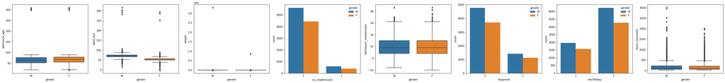

```python
n_cols = len(demographics)
plt.subplots(1, len(demographics), figsize=(50,5))
for i in range(n_cols):
    plt.subplot(1, n_cols, i+1)
    if is_numeric_dtype(patients[demographics[i]]):
        sns.boxplot(data=patients, x='gender', y=demographics[i], orient='v')
    else:
        sns.countplot(data=patients, x=demographics[i], orient='v', hue='gender')
```

## Mechvent events

Create a single mechanical ventilation event per icustay. Peine et. al simply sample the first recorded mechvent event.

- for each patient:
  - count each consecutive mechvent using mechvent_start_peine
  - assign this count label to each timestep at which mechvent_peine is true
  - calculate timestep before and 18 (=72/4) timesteps after onset of mechanical ventilation
  - filter by these calculated timesteps

```python
def reverse_cumsum_reset(series):
    """
    Calculates a cumulative sum for a series with the following alterations:
    * resets the aggregate when a 0 value is encountered
    * calculates the aggregate in reverse, i.e. a reverse of the series
    """
    return list(itertools.accumulate(series.iloc[::-1], lambda agg, x: 0 if x == 0 else x+agg))[::-1]
# assign durations to the mech vent events
grouped_reverse = df.sort_values('start_time').groupby('icustay_id')
len_mechvents = grouped_reverse['mechvent_peine'].apply(reverse_cumsum_reset)
df['mechvent_peine_duration_countdown_h'] = len_mechvents.to_frame().explode('mechvent_peine').reset_index()['mechvent_peine'] * SAMPLE_TIME_H
```

```python
def mechvent_event_count(df):
    """
    Returns that assignes per-icustay count to each separate mechanical ventilation event.
    """
    grouped = df.groupby('icustay_id')
    vent_event_count = grouped['mechvent_start_peine'].cumsum()
    return vent_event_count

df['mechvent_count_peine'] = mechvent_event_count(df)
```

```python
# the 'left' edge of the selection interval is one timestep (4hours) before the onset of the first mech vent event
df['selection_left_peine_unshift'] = ((df['mechvent_start_peine'] == 1.0) & (df['mechvent_count_peine'] == 1.0))
df['selection_left_peine'] = df.groupby('icustay_id')['selection_left_peine_unshift'].shift(-1)
# the 'right' edige of the selection interval is 18 timesteps (72 hours) after the onset of the first mech vent event
df['selection_right_peine_unshift'] = ((df['mechvent_start_peine'] == 1.0) & (df['mechvent_count_peine'] == 1.0))
df['selection_right_peine'] = df.groupby('icustay_id')['selection_right_peine_unshift'].shift(18)
# put the edges into a sparse series, i.e. with value 1 for interval edges and NaN otherwise
df['selection_edges_peine'] = df['selection_left_peine'] | df['selection_right_peine']
df['selection_edges_peine_int'] = df['selection_edges_peine'].astype('int64')
df.loc[~(df['selection_edges_peine_int'] == 1.0), 'selection_edges_peine_int'] = np.NaN
# now fill the area inside the edges with interpolate.
df['selection_peine'] = df.groupby('icustay_id')['selection_edges_peine_int'].apply(lambda g: g.interpolate(limit_area='inside'))
```

# Imputation

Steps according to Peine et al.

- Time-windowed sample-and-hold e.g. forward-fill.

  Windows sizes were determined using a frequency analysis of the dataset, producing the frequency of production of a new datapoint (per variable)
- K-nearest neighbor imputation with imputation and SVD
- If >50% of missing data, discard (<1% of cohort)
- Test correlation between data and probability distribution of missing values for each of the 44 features. Here, GCS was associated with highest p-value of 0.08 -> hence distinguish missing-at-random from missing-completely-at-random and not-missed-at-random.

## Determine sample-and-hold window with frequency analysis

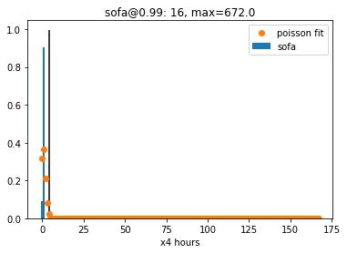

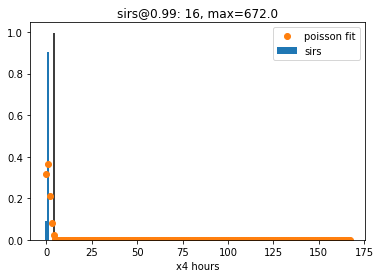

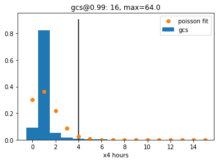

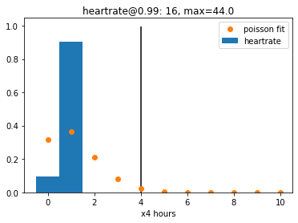

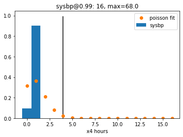

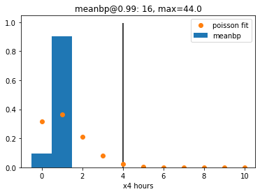

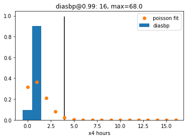

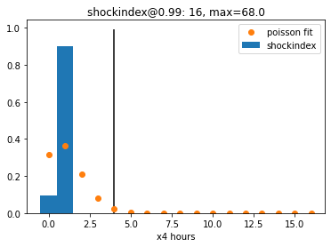

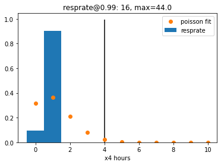

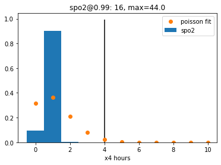

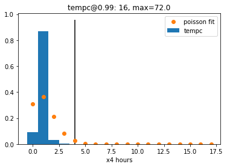

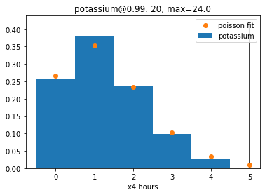

[33 more figures not shown]

```python
def ffill_window(df, var, plot, scope_filter):
    val = get_cutoff_duration(df, var, quantile=.99, plot=plot, scope_filter=scope_filter)
    if not plot:
        print('.', end='') # simple measure of progress
    return val

all_var_types = [
    vital_sign_vars,
    lab_vars,
    treatment_vars,
    vent_vars,
    guideline_vars,
]
all_vars = functools.reduce(operator.add, all_var_types)

# NOTE: embarrasingly parallel, can be sped up with e.g. joblib.Parallel
ffill_windows = {var: ffill_window(df, var, True, df['selection_peine'] == 1.0) for var in all_vars}
```

## Impute by sample-and-hold

```python
for var in all_vars:
    df[var + '_imp'] = df.groupby('icustay_id')[var].ffill(limit=ffill_windows[var])

imputed_vars = list(map(lambda x: x + '_imp', all_vars))
```

```python
max_varname_len = max(map(len, all_vars))
print("{}: {}  {}  {}".format('VARNAME'.ljust(max_varname_len), 'MISSING', 'ORIGINAL', 'IMPUTED'))
for var in all_vars:
    missing = df[var].isna().sum() / df.shape[0]
    missing_imp = df[var + '_imp'].isna().sum() / df.shape[0]
    imputed = missing - missing_imp
    print("{}: {:.4f}   {:.4f}    {:.4f}".format(
        var.ljust(max_varname_len),
        missing_imp,
        missing,
        imputed))
```

```
VARNAME          : MISSING  ORIGINAL  IMPUTED
sofa             : 0.0000   0.0000    0.0000
sirs             : 0.0000   0.0000    0.0000
gcs              : 0.0142   0.1912    0.1770
heartrate        : 0.0060   0.0140    0.0080
sysbp            : 0.0081   0.0247    0.0165
meanbp           : 0.0062   0.0180    0.0118
diasbp           : 0.0082   0.0247    0.0165
shockindex       : 0.0096   0.0321    0.0225
resprate         : 0.0060   0.0171    0.0111
spo2             : 0.0066   0.0215    0.0149
tempc            : 0.0140   0.0947    0.0806
potassium        : 0.6539   0.9596    0.3057
sodium           : 0.6531   0.9605    0.3074
chloride         : 0.6516   0.9605    0.3089
glucose          : 0.6588   0.9625    0.3038
bun              : 0.6498   0.9599    0.3101
creatinine       : 0.6498   0.9598    0.3101
magnesium        : 0.6641   0.9641    0.3000
calcium          : 0.6884   0.9685    0.2801
ionizedcalcium   : 0.3309   0.8289    0.4980
carbondioxide    : 0.7161   0.9456    0.2295
bilirubin        : 0.8141   0.9865    0.1723
albumin          : 0.8727   0.9903    0.1177
hemoglobin       : 0.7076   0.9625    0.2549
wbc              : 0.7075   0.9627    0.2551
platelet         : 0.7053   0.9608    0.2555
ptt              : 0.7304   0.9668    0.2363
pt               : 0.7293   0.9666    0.2373
inr              : 0.7293   0.9666    0.2373
ph               : 0.7131   0.9444    0.2313
pao2             : 0.8296   0.9798    0.1503
paco2            : 0.7270   0.9495    0.2225
base_excess      : 0.7260   0.9497    0.2237
bicarbonate      : 0.6521   0.9610    0.3090
lactate          : 0.7696   0.9675    0.1979
pao2fio2ratio    : 0.8326   0.9844    0.1518
iv_total         : 0.0162   0.1476    0.1315
vaso_total       : 0.6212   0.8881    0.2669
urineoutput      : 0.0908   0.1471    0.0563
cum_fluid_balance: 0.0212   0.0360    0.0148
peep             : 0.1279   0.3610    0.2331
fio2             : 0.0727   0.2776    0.2049
tidal_volume     : 0.1280   0.3614    0.2334
mechvent         : 0.0025   0.0044    0.0019
plateau_pressure : 0.5756   0.8188    0.2432
```

# Missing values selection

```python
selection = df[df['selection_peine'] == 1.0]

max_varname_len = max(map(len, all_vars))
print("{}: {}  {}  {}".format('VARNAME'.ljust(max_varname_len), 'MISSING', 'ORIGINAL', 'IMPUTED'))
for var in all_vars:
    missing = selection[var].isna().sum() / selection.shape[0]
    missing_imp = selection[var + '_imp'].isna().sum() / selection.shape[0]
    imputed = missing - missing_imp
    print("{}: {:.4f}   {:.4f}    {:.4f}".format(
        var.ljust(max_varname_len),
        missing_imp,
        missing,
        imputed))
```

```
VARNAME          : MISSING  ORIGINAL  IMPUTED
sofa             : 0.0000   0.0000    0.0000
sirs             : 0.0000   0.0000    0.0000
gcs              : 0.0380   0.2041    0.1661
heartrate        : 0.0206   0.0257    0.0051
sysbp            : 0.0217   0.0380    0.0163
meanbp           : 0.0207   0.0273    0.0065
diasbp           : 0.0218   0.0381    0.0163
shockindex       : 0.0227   0.0424    0.0197
resprate         : 0.0205   0.0277    0.0072
spo2             : 0.0211   0.0309    0.0098
tempc            : 0.0414   0.1043    0.0630
potassium        : 0.1330   0.9120    0.7790
sodium           : 0.1298   0.9139    0.7842
chloride         : 0.1227   0.9123    0.7897
glucose          : 0.1424   0.9193    0.7770
bun              : 0.1185   0.9115    0.7930
creatinine       : 0.1185   0.9113    0.7928
magnesium        : 0.1570   0.9213    0.7643
calcium          : 0.2215   0.9336    0.7120
ionizedcalcium   : 0.2541   0.7335    0.4793
carbondioxide    : 0.2138   0.8553    0.6415
bilirubin        : 0.5104   0.9715    0.4611
albumin          : 0.6572   0.9805    0.3232
hemoglobin       : 0.1944   0.9149    0.7205
wbc              : 0.1939   0.9157    0.7218
platelet         : 0.1867   0.9093    0.7226
ptt              : 0.2578   0.9231    0.6653
pt               : 0.2537   0.9221    0.6684
inr              : 0.2539   0.9221    0.6682
ph               : 0.2060   0.8524    0.6465
pao2             : 0.4948   0.9461    0.4512
paco2            : 0.2430   0.8642    0.6212
base_excess      : 0.2396   0.8656    0.6260
bicarbonate      : 0.1230   0.9138    0.7907
lactate          : 0.3459   0.9137    0.5678
pao2fio2ratio    : 0.5843   0.9579    0.3736
iv_total         : 0.0262   0.0975    0.0712
vaso_total       : 0.4765   0.8071    0.3306
urineoutput      : 0.0733   0.1191    0.0458
cum_fluid_balance: 0.0418   0.0497    0.0078
peep             : 0.0459   0.2575    0.2115
fio2             : 0.0582   0.2234    0.1651
tidal_volume     : 0.0456   0.2587    0.2130
mechvent         : 0.0104   0.0109    0.0006
plateau_pressure : 0.4789   0.7469    0.2680
```

Remove patients with too many missing values

```python
to_remove = ((selection[imputed_vars].isnull().groupby(df.icustay_id).mean().mean(axis=1)) > .5)
print("Removing {} / {} = {}% patients due to >50% missing values".format(to_remove.sum(), selection.shape[0], 100*to_remove.sum()/selection.shape[0]))
selection = selection[~selection.icustay_id.isin(to_remove[to_remove].index)]
selected_patients = selection.drop_duplicates(subset='icustay_id', keep='first')

print("Selection of {} timesteps for {} patients / mech vent events".format(selection.shape[0], selected_patients.shape[0]))
```

```
Removing 450 / 109112 = 0.41242026541535304% patients due to >50% missing values
Selection of 102810 timesteps for 10299 patients / mech vent events
```

# Outlier removal

"Outliers were sorted out with univariate statistical approaches (Tukey's range test) and frequency analysis (90% CI)" according to Peine. Since Tukey's range test is a test for significantly different means between groups, they probably refer to Tukey's fences for outlier detection, which are defines 'non outlier' data as everything in the range `[(first quartile - 1.5 IQR), (third quartile + 1.5 IQR)]`.

```python
tukeys_fences = []
for var in all_vars:
    if pd.api.types.is_numeric_dtype(selection[var]):
        selection[var + '_in_tukeys_fence'] = tukeys_fence(selection[var])
        tukeys_fences += [var + '_in_tukeys_fence',]
```

```python
for var in all_vars:
    if pd.api.types.is_numeric_dtype(selection[var]):
        selection.loc[~selection[var + '_in_tukeys_fence'], var] = np.NaN
        selection.loc[~selection[var + '_in_tukeys_fence'], var + '_imp'] = np.NaN
```

```python
# TODO: per-icustay outlier removal for demographics
# for var in demographics:
#     if pd.api.types.is_numeric_dtype(selected_patients[var]):
#         selection.loc[selected_patients.index, var + '_in_tukeys_fence'] = tukeys_fence(df[var])
#         fenced_icustay_ids = selection.
#         selection.loc[~selection[var + '_in_tukeys_fence'], var] = np.NaN
#         selection.loc[~selection[var + '_in_tukeys_fence'], var + '_imp'] = np.NaN
```